# Risk Factor Analysis

## Outcome Variable

**Outcome Variable:** co_occurence

## Predictor Variables

**Intervention Variable:** ever_sstunted06

**Adjustment Set:**

unadjusted

## Stratifying Variables

The analysis was stratified on these variable(s):

- studyid
- country

## Data Summary

| studyid | country | ever_sstunted06 | co_occurence | n_cell | n |
| --- | --- | --- | --- | --- | --- |
| ki0047075b-MAL-ED | BANGLADESH | 0 | 0 | 196 | 221 |
| ki0047075b-MAL-ED | BANGLADESH | 0 | 1 | 12 | 221 |
| ki0047075b-MAL-ED | BANGLADESH | 1 | 0 | 11 | 221 |
| ki0047075b-MAL-ED | BANGLADESH | 1 | 1 | 2 | 221 |
| ki0047075b-MAL-ED | BRAZIL | 0 | 0 | 171 | 180 |
| ki0047075b-MAL-ED | BRAZIL | 0 | 1 | 0 | 180 |
| ki0047075b-MAL-ED | BRAZIL | 1 | 0 | 8 | 180 |
| ki0047075b-MAL-ED | BRAZIL | 1 | 1 | 1 | 180 |
| ki0047075b-MAL-ED | INDIA | 0 | 0 | 196 | 228 |
| ki0047075b-MAL-ED | INDIA | 0 | 1 | 14 | 228 |
| ki0047075b-MAL-ED | INDIA | 1 | 0 | 15 | 228 |
| ki0047075b-MAL-ED | INDIA | 1 | 1 | 3 | 228 |
| ki0047075b-MAL-ED | NEPAL | 0 | 0 | 218 | 229 |
| ki0047075b-MAL-ED | NEPAL | 0 | 1 | 4 | 229 |
| ki0047075b-MAL-ED | NEPAL | 1 | 0 | 7 | 229 |
| ki0047075b-MAL-ED | NEPAL | 1 | 1 | 0 | 229 |
| ki0047075b-MAL-ED | PERU | 0 | 0 | 192 | 222 |
| ki0047075b-MAL-ED | PERU | 0 | 1 | 2 | 222 |
| ki0047075b-MAL-ED | PERU | 1 | 0 | 24 | 222 |
| ki0047075b-MAL-ED | PERU | 1 | 1 | 4 | 222 |
| ki0047075b-MAL-ED | SOUTH AFRICA | 0 | 0 | 215 | 241 |
| ki0047075b-MAL-ED | SOUTH AFRICA | 0 | 1 | 3 | 241 |
| ki0047075b-MAL-ED | SOUTH AFRICA | 1 | 0 | 22 | 241 |
| ki0047075b-MAL-ED | SOUTH AFRICA | 1 | 1 | 1 | 241 |
| ki0047075b-MAL-ED | TANZANIA, UNITED REPUBLIC OF | 0 | 0 | 197 | 225 |
| ki0047075b-MAL-ED | TANZANIA, UNITED REPUBLIC OF | 0 | 1 | 0 | 225 |
| ki0047075b-MAL-ED | TANZANIA, UNITED REPUBLIC OF | 1 | 0 | 27 | 225 |
| ki0047075b-MAL-ED | TANZANIA, UNITED REPUBLIC OF | 1 | 1 | 1 | 225 |
| ki1000107-Serrinha-VitA | BRAZIL | 0 | 0 | 10 | 10 |
| ki1000107-Serrinha-VitA | BRAZIL | 0 | 1 | 0 | 10 |

[output cut: 118 more lines]

The following strata were considered:

- studyid: ki0047075b-MAL-ED, country: BANGLADESH
- studyid: ki0047075b-MAL-ED, country: BRAZIL
- studyid: ki0047075b-MAL-ED, country: INDIA
- studyid: ki0047075b-MAL-ED, country: NEPAL
- studyid: ki0047075b-MAL-ED, country: PERU
- studyid: ki0047075b-MAL-ED, country: SOUTH AFRICA
- studyid: ki0047075b-MAL-ED, country: TANZANIA, UNITED REPUBLIC OF
- studyid: ki1000107-Serrinha-VitA, country: BRAZIL
- studyid: ki1000108-CMC-V-BCS-2002, country: INDIA
- studyid: ki1000108-IRC, country: INDIA
- studyid: ki1000109-EE, country: PAKISTAN
- studyid: ki1000109-ResPak, country: PAKISTAN
- studyid: ki1000110-WASH-Bangladesh, country: BANGLADESH
- studyid: ki1000111-WASH-Kenya, country: KENYA
- studyid: ki1000304b-SAS-CompFeed, country: INDIA
- studyid: ki1000304b-SAS-FoodSuppl, country: INDIA
- studyid: ki1017093-NIH-Birth, country: BANGLADESH
- studyid: ki1017093b-PROVIDE, country: BANGLADESH
- studyid: ki1017093c-NIH-Crypto, country: BANGLADESH
- studyid: ki1033518-iLiNS-DYAD-G, country: GHANA
- studyid: ki1066203-TanzaniaChild2, country: TANZANIA, UNITED REPUBLIC OF
- studyid: ki1101329-Keneba, country: GAMBIA
- studyid: ki1112895-Burkina Faso Zn, country: BURKINA FASO
- studyid: ki1113344-GMS-Nepal, country: NEPAL
- studyid: ki1114097-CMIN, country: BANGLADESH
- studyid: ki1114097-CMIN, country: BRAZIL
- studyid: ki1114097-CMIN, country: GUINEA-BISSAU
- studyid: ki1114097-CMIN, country: PERU
- studyid: ki1114097-CONTENT, country: PERU
- studyid: ki1119695-PROBIT, country: BELARUS
- studyid: ki1126311-ZVITAMBO, country: ZIMBABWE
- studyid: ki1135781-COHORTS, country: GUATEMALA
- studyid: ki1135781-COHORTS, country: PHILIPPINES
- studyid: ki1148112-iLiNS-DOSE, country: MALAWI
- studyid: ki1148112-iLiNS-DYAD-M, country: MALAWI
- studyid: ki1148112-LCNI-5, country: MALAWI
- studyid: kiGH5241-JiVitA-4, country: BANGLADESH

### Dropped Strata

Some strata were dropped due to rare outcomes:

- studyid: ki0047075b-MAL-ED, country: BANGLADESH
- studyid: ki0047075b-MAL-ED, country: BRAZIL
- studyid: ki0047075b-MAL-ED, country: INDIA
- studyid: ki0047075b-MAL-ED, country: NEPAL
- studyid: ki0047075b-MAL-ED, country: PERU
- studyid: ki0047075b-MAL-ED, country: SOUTH AFRICA
- studyid: ki0047075b-MAL-ED, country: TANZANIA, UNITED REPUBLIC OF
- studyid: ki1000107-Serrinha-VitA, country: BRAZIL
- studyid: ki1000109-ResPak, country: PAKISTAN
- studyid: ki1000110-WASH-Bangladesh, country: BANGLADESH
- studyid: ki1000111-WASH-Kenya, country: KENYA
- studyid: ki1017093b-PROVIDE, country: BANGLADESH
- studyid: ki1033518-iLiNS-DYAD-G, country: GHANA
- studyid: ki1066203-TanzaniaChild2, country: TANZANIA, UNITED REPUBLIC OF
- studyid: ki1112895-Burkina Faso Zn, country: BURKINA FASO
- studyid: ki1114097-CMIN, country: BRAZIL
- studyid: ki1114097-CMIN, country: GUINEA-BISSAU
- studyid: ki1114097-CMIN, country: PERU
- studyid: ki1114097-CONTENT, country: PERU
- studyid: ki1119695-PROBIT, country: BELARUS
- studyid: ki1148112-iLiNS-DYAD-M, country: MALAWI
- studyid: ki1148112-LCNI-5, country: MALAWI

## Methods Detail

We’re interested in the causal parameters $E[Y_a]$ for all values of $a \in \mathcal{A}$. These parameters represent the mean outcome if, possibly contrary to fact, we intervened to set all units to have $A=a$. Under the randomization and positivity assumptions, these are identified by the statistical parameters $\psi_a=E_W[E_{Y|A,W}(Y|A=a,W)]$. In addition, we’re interested in the mean of $Y$, $E[Y]$ under no intervention (the observed mean). We will estimate these parameters by using SuperLearner to fit the relevant likelihood factors – $E_{Y|A,W}(Y|A=a,W)$ and $p(A=a|W)$, and then updating our likelihood fit using a joint TMLE.

For unadjusted analyses ($W=\{\}$), initial likelihoods were estimated using Lrnr_glm to estimate the simple $E(Y|A)$ and Lrnr_mean to estimate $p(A)$. For adjusted analyses, a small library containing Lrnr_glmnet, Lrnr_xgboost, and Lrnr_mean was used.

Having estimated these parameters, we will then use the delta method to estimate relative risks and attributable risks relative to a prespecified baseline level of $A$.

# Results Detail

## Results Plots

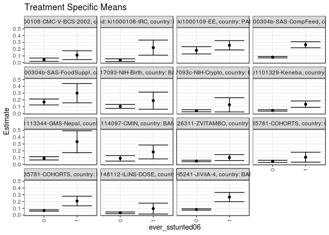

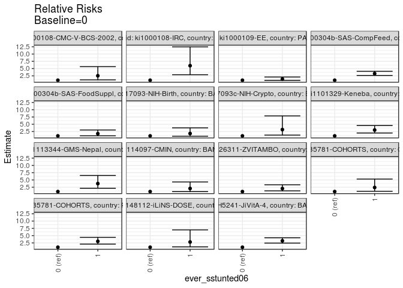

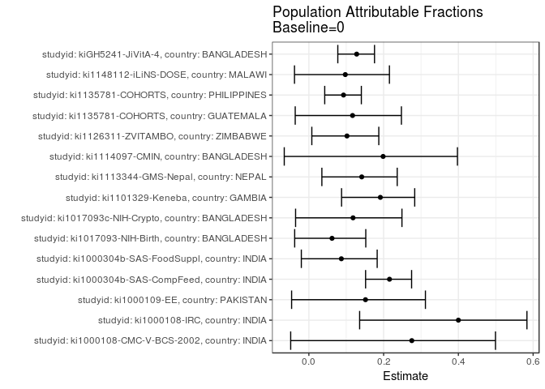

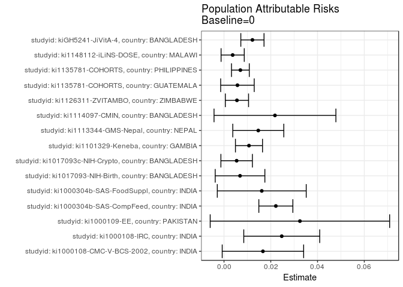

## Results Table

### Parameter: TSM

| studyid | country | intervention_level | baseline_level | estimate | ci_lower | ci_upper |
| --- | --- | --- | --- | --- | --- | --- |
| ki1000108-CMC-V-BCS-2002 | INDIA | 0 | NA | 0.0437956 | 0.0195317 | 0.0680595 |
| ki1000108-CMC-V-BCS-2002 | INDIA | 1 | NA | 0.1111111 | 0.0460941 | 0.1761281 |
| ki1000108-IRC | INDIA | 0 | NA | 0.0370370 | 0.0172558 | 0.0568183 |
| ki1000108-IRC | INDIA | 1 | NA | 0.2222222 | 0.1112001 | 0.3332444 |
| ki1000109-EE | PAKISTAN | 0 | NA | 0.1818182 | 0.1280184 | 0.2356179 |
| ki1000109-EE | PAKISTAN | 1 | NA | 0.2565789 | 0.1870484 | 0.3261095 |
| ki1000304b-SAS-CompFeed | INDIA | 0 | NA | 0.0806159 | 0.0701338 | 0.0910981 |
| ki1000304b-SAS-CompFeed | INDIA | 1 | NA | 0.2649007 | 0.2205470 | 0.3092543 |
| ki1000304b-SAS-FoodSuppl | INDIA | 0 | NA | 0.1696113 | 0.1258192 | 0.2134035 |
| ki1000304b-SAS-FoodSuppl | INDIA | 1 | NA | 0.3000000 | 0.1577668 | 0.4422332 |
| ki1017093-NIH-Birth | BANGLADESH | 0 | NA | 0.1037736 | 0.0747140 | 0.1328331 |
| ki1017093-NIH-Birth | BANGLADESH | 1 | NA | 0.1891892 | 0.0628533 | 0.3155251 |
| ki1017093c-NIH-Crypto | BANGLADESH | 0 | NA | 0.0403361 | 0.0245149 | 0.0561573 |
| ki1017093c-NIH-Crypto | BANGLADESH | 1 | NA | 0.1282051 | 0.0231981 | 0.2332122 |
| ki1101329-Keneba | GAMBIA | 0 | NA | 0.0451613 | 0.0348205 | 0.0555021 |
| ki1101329-Keneba | GAMBIA | 1 | NA | 0.1365854 | 0.0895628 | 0.1836080 |
| ki1113344-GMS-Nepal | NEPAL | 0 | NA | 0.0889749 | 0.0644110 | 0.1135387 |
| ki1113344-GMS-Nepal | NEPAL | 1 | NA | 0.3333333 | 0.1723503 | 0.4943163 |
| ki1114097-CMIN | BANGLADESH | 0 | NA | 0.0879121 | 0.0466859 | 0.1291383 |
| ki1114097-CMIN | BANGLADESH | 1 | NA | 0.1818182 | 0.0796705 | 0.2839659 |
| ki1126311-ZVITAMBO | ZIMBABWE | 0 | NA | 0.0487475 | 0.0377621 | 0.0597328 |
| ki1126311-ZVITAMBO | ZIMBABWE | 1 | NA | 0.0994475 | 0.0558370 | 0.1430580 |
| ki1135781-COHORTS | GUATEMALA | 0 | NA | 0.0434109 | 0.0276734 | 0.0591483 |
| ki1135781-COHORTS | GUATEMALA | 1 | NA | 0.1044776 | 0.0311841 | 0.1777712 |
| ki1135781-COHORTS | PHILIPPINES | 0 | NA | 0.0685279 | 0.0583413 | 0.0787145 |
| ki1135781-COHORTS | PHILIPPINES | 1 | NA | 0.2080000 | 0.1368337 | 0.2791663 |
| ki1148112-iLiNS-DOSE | MALAWI | 0 | NA | 0.0343137 | 0.0218167 | 0.0468107 |
| ki1148112-iLiNS-DOSE | MALAWI | 1 | NA | 0.0961538 | 0.0159810 | 0.1763267 |
| kiGH5241-JiVitA-4 | BANGLADESH | 0 | NA | 0.0828689 | 0.0729176 | 0.0928202 |
| kiGH5241-JiVitA-4 | BANGLADESH | 1 | NA | 0.2662116 | 0.1990458 | 0.3333774 |

### Parameter: E(Y)

| studyid | country | intervention_level | baseline_level | estimate | ci_lower | ci_upper |
| --- | --- | --- | --- | --- | --- | --- |
| ki1000108-CMC-V-BCS-2002 | INDIA | NA | NA | 0.0604396 | 0.0359254 | 0.0849538 |
| ki1000108-IRC | INDIA | NA | NA | 0.0617284 | 0.0382610 | 0.0851958 |
| ki1000109-EE | PAKISTAN | NA | NA | 0.2142857 | 0.1712366 | 0.2573348 |
| ki1000304b-SAS-CompFeed | INDIA | NA | NA | 0.1027888 | 0.0905676 | 0.1150101 |
| ki1000304b-SAS-FoodSuppl | INDIA | NA | NA | 0.1857585 | 0.1432798 | 0.2282372 |
| ki1017093-NIH-Birth | BANGLADESH | NA | NA | 0.1106291 | 0.0819645 | 0.1392936 |
| ki1017093c-NIH-Crypto | BANGLADESH | NA | NA | 0.0457413 | 0.0294659 | 0.0620168 |
| ki1101329-Keneba | GAMBIA | NA | NA | 0.0558405 | 0.0450949 | 0.0665861 |
| ki1113344-GMS-Nepal | NEPAL | NA | NA | 0.1036364 | 0.0781411 | 0.1291317 |
| ki1114097-CMIN | BANGLADESH | NA | NA | 0.1097046 | 0.0698323 | 0.1495770 |
| ki1126311-ZVITAMBO | ZIMBABWE | NA | NA | 0.0542823 | 0.0433730 | 0.0651916 |
| ki1135781-COHORTS | GUATEMALA | NA | NA | 0.0491573 | 0.0332659 | 0.0650487 |
| ki1135781-COHORTS | PHILIPPINES | NA | NA | 0.0755323 | 0.0651490 | 0.0859156 |
| ki1148112-iLiNS-DOSE | MALAWI | NA | NA | 0.0380184 | 0.0252887 | 0.0507482 |
| kiGH5241-JiVitA-4 | BANGLADESH | NA | NA | 0.0950226 | 0.0844790 | 0.1055662 |

### Parameter: RR

| studyid | country | intervention_level | baseline_level | estimate | ci_lower | ci_upper |
| --- | --- | --- | --- | --- | --- | --- |
| ki1000108-CMC-V-BCS-2002 | INDIA | 0 | 0 | 1.000000 | 1.0000000 | 1.000000 |
| ki1000108-CMC-V-BCS-2002 | INDIA | 1 | 0 | 2.537037 | 1.1333470 | 5.679246 |
| ki1000108-IRC | INDIA | 0 | 0 | 1.000000 | 1.0000000 | 1.000000 |
| ki1000108-IRC | INDIA | 1 | 0 | 6.000000 | 2.8875852 | 12.467165 |
| ki1000109-EE | PAKISTAN | 0 | 0 | 1.000000 | 1.0000000 | 1.000000 |
| ki1000109-EE | PAKISTAN | 1 | 0 | 1.411184 | 0.9447746 | 2.107848 |
| ki1000304b-SAS-CompFeed | INDIA | 0 | 0 | 1.000000 | 1.0000000 | 1.000000 |
| ki1000304b-SAS-CompFeed | INDIA | 1 | 0 | 3.285959 | 2.6431940 | 4.085029 |
| ki1000304b-SAS-FoodSuppl | INDIA | 0 | 0 | 1.000000 | 1.0000000 | 1.000000 |
| ki1000304b-SAS-FoodSuppl | INDIA | 1 | 0 | 1.768750 | 1.0308851 | 3.034748 |
| ki1017093-NIH-Birth | BANGLADESH | 0 | 0 | 1.000000 | 1.0000000 | 1.000000 |
| ki1017093-NIH-Birth | BANGLADESH | 1 | 0 | 1.823096 | 0.8837535 | 3.760866 |
| ki1017093c-NIH-Crypto | BANGLADESH | 0 | 0 | 1.000000 | 1.0000000 | 1.000000 |
| ki1017093c-NIH-Crypto | BANGLADESH | 1 | 0 | 3.178419 | 1.2817866 | 7.881457 |
| ki1101329-Keneba | GAMBIA | 0 | 0 | 1.000000 | 1.0000000 | 1.000000 |
| ki1101329-Keneba | GAMBIA | 1 | 0 | 3.024390 | 2.0001949 | 4.573022 |
| ki1113344-GMS-Nepal | NEPAL | 0 | 0 | 1.000000 | 1.0000000 | 1.000000 |
| ki1113344-GMS-Nepal | NEPAL | 1 | 0 | 3.746377 | 2.1479194 | 6.534388 |
| ki1114097-CMIN | BANGLADESH | 0 | 0 | 1.000000 | 1.0000000 | 1.000000 |
| ki1114097-CMIN | BANGLADESH | 1 | 0 | 2.068182 | 0.9948736 | 4.299417 |
| ki1126311-ZVITAMBO | ZIMBABWE | 0 | 0 | 1.000000 | 1.0000000 | 1.000000 |
| ki1126311-ZVITAMBO | ZIMBABWE | 1 | 0 | 2.040055 | 1.2459959 | 3.340160 |
| ki1135781-COHORTS | GUATEMALA | 0 | 0 | 1.000000 | 1.0000000 | 1.000000 |
| ki1135781-COHORTS | GUATEMALA | 1 | 0 | 2.406716 | 1.0926494 | 5.301137 |
| ki1135781-COHORTS | PHILIPPINES | 0 | 0 | 1.000000 | 1.0000000 | 1.000000 |
| ki1135781-COHORTS | PHILIPPINES | 1 | 0 | 3.035259 | 2.0901896 | 4.407638 |
| ki1148112-iLiNS-DOSE | MALAWI | 0 | 0 | 1.000000 | 1.0000000 | 1.000000 |
| ki1148112-iLiNS-DOSE | MALAWI | 1 | 0 | 2.802198 | 1.1281021 | 6.960640 |
| kiGH5241-JiVitA-4 | BANGLADESH | 0 | 0 | 1.000000 | 1.0000000 | 1.000000 |
| kiGH5241-JiVitA-4 | BANGLADESH | 1 | 0 | 3.212442 | 2.4293693 | 4.247928 |

### Parameter: PAR

| studyid | country | intervention_level | baseline_level | estimate | ci_lower | ci_upper |
| --- | --- | --- | --- | --- | --- | --- |
| ki1000108-CMC-V-BCS-2002 | INDIA | 0 | NA | 0.0166439 | -0.0007728 | 0.0340607 |
| ki1000108-IRC | INDIA | 0 | NA | 0.0246914 | 0.0084505 | 0.0409322 |
| ki1000109-EE | PAKISTAN | 0 | NA | 0.0324675 | -0.0059098 | 0.0708448 |
| ki1000304b-SAS-CompFeed | INDIA | 0 | NA | 0.0221729 | 0.0148986 | 0.0294472 |
| ki1000304b-SAS-FoodSuppl | INDIA | 0 | NA | 0.0161472 | -0.0028705 | 0.0351649 |
| ki1017093-NIH-Birth | BANGLADESH | 0 | NA | 0.0068555 | -0.0037630 | 0.0174740 |
| ki1017093c-NIH-Crypto | BANGLADESH | 0 | NA | 0.0054052 | -0.0013310 | 0.0121414 |
| ki1101329-Keneba | GAMBIA | 0 | NA | 0.0106792 | 0.0048898 | 0.0164685 |
| ki1113344-GMS-Nepal | NEPAL | 0 | NA | 0.0146615 | 0.0037513 | 0.0255717 |
| ki1114097-CMIN | BANGLADESH | 0 | NA | 0.0217926 | -0.0042660 | 0.0478511 |
| ki1126311-ZVITAMBO | ZIMBABWE | 0 | NA | 0.0055348 | 0.0005666 | 0.0105031 |
| ki1135781-COHORTS | GUATEMALA | 0 | NA | 0.0057465 | -0.0014285 | 0.0129214 |
| ki1135781-COHORTS | PHILIPPINES | 0 | NA | 0.0070044 | 0.0032007 | 0.0108081 |
| ki1148112-iLiNS-DOSE | MALAWI | 0 | NA | 0.0037047 | -0.0012535 | 0.0086629 |
| kiGH5241-JiVitA-4 | BANGLADESH | 0 | NA | 0.0121537 | 0.0071915 | 0.0171159 |

### Parameter: PAF

| studyid | country | intervention_level | baseline_level | estimate | ci_lower | ci_upper |
| --- | --- | --- | --- | --- | --- | --- |
| ki1000108-CMC-V-BCS-2002 | INDIA | 0 | NA | 0.2753815 | -0.0486385 | 0.4992823 |
| ki1000108-IRC | INDIA | 0 | NA | 0.4000000 | 0.1358161 | 0.5834220 |
| ki1000109-EE | PAKISTAN | 0 | NA | 0.1515152 | -0.0461619 | 0.3118402 |
| ki1000304b-SAS-CompFeed | INDIA | 0 | NA | 0.2157131 | 0.1517610 | 0.2748436 |
| ki1000304b-SAS-FoodSuppl | INDIA | 0 | NA | 0.0869258 | -0.0201473 | 0.1827607 |
| ki1017093-NIH-Birth | BANGLADESH | 0 | NA | 0.0619682 | -0.0379509 | 0.1522685 |
| ki1017093c-NIH-Crypto | BANGLADESH | 0 | NA | 0.1181686 | -0.0355110 | 0.2490408 |
| ki1101329-Keneba | GAMBIA | 0 | NA | 0.1912442 | 0.0875202 | 0.2831777 |
| ki1113344-GMS-Nepal | NEPAL | 0 | NA | 0.1414707 | 0.0347873 | 0.2363625 |
| ki1114097-CMIN | BANGLADESH | 0 | NA | 0.1986475 | -0.0658383 | 0.3975016 |
| ki1126311-ZVITAMBO | ZIMBABWE | 0 | NA | 0.1019634 | 0.0079124 | 0.1870984 |
| ki1135781-COHORTS | GUATEMALA | 0 | NA | 0.1168992 | -0.0365005 | 0.2475961 |
| ki1135781-COHORTS | PHILIPPINES | 0 | NA | 0.0927341 | 0.0424238 | 0.1404011 |
| ki1148112-iLiNS-DOSE | MALAWI | 0 | NA | 0.0974450 | -0.0384270 | 0.2155390 |
| kiGH5241-JiVitA-4 | BANGLADESH | 0 | NA | 0.1279034 | 0.0774282 | 0.1756169 |